# Risk Premium Modeling

# Abstract.

### Loading Packages

```r
library(glm2)
library(ggplot2)
library(coefplot)
```

### Downloading the data

```r
ACollison<-read.csv("AutoCollision.csv")
```

### Data preview

```r
str(ACollison)
```

```
## 'data.frame':    32 obs. of  6 variables:
##  $ Age        : Factor w/ 8 levels "1720","2124",..: 1 1 1 1 2 2 2 2 3 3 ...
##  $ Vehicle_Use: Factor w/ 4 levels "Business","DriveLong",..: 4 3 2 1 4 3 2 1 4 3 ...
##  $ Severity   : num  250 275 245 798 214 ...
##  $ NumClaims  : int  21 40 23 5 63 171 92 44 140 343 ...
##  $ Exposure   : int  1342 2556 1470 319 4025 10926 5879 2811 8946 21917 ...
##  $ ClaimCost  : num  5260 10991 5624 3989 13464 ...
```

# Data Modeling

## Number of Claims Modeling and Analysis

I first evaluated the significance of variables using AOV and GLM. AOV, analogous to SAS's type 3 error test, determines variable significance under the F-test.

A three-star rating in the output indicates high significance. The GLM package was then employed to fit the data to a Poisson distribution.

```r
Numtype3<-aov(NumClaims~Vehicle_Use+Age, data=ACollison)
summary(Numtype3)
```

```
##             Df Sum Sq Mean Sq F value   Pr(>F)
## Vehicle_Use  3 654599  218200  14.795 2.11e-05 ***
## Age          7 845293  120756   8.188 7.78e-05 ***
## Residuals   21 309714   14748
## ---
## Signif. codes:  0 '***' 0.001 '**' 0.01 '*' 0.05 '.' 0.1 ' ' 1
```

The summary of this model highlights the significance of covariates with respect to the reference variables, which in this case are 'Vehicle_useBusiness' and 'Age17-20'.

```r
modCount <- glm(NumClaims ~ Vehicle_Use + Age, offset(log(Exposure)), data = ACollison,
    family = poisson(link = "log"))
summary(modCount)
```

```
##
## Call:
## glm(formula = NumClaims ~ Vehicle_Use + Age, family = poisson(link = "log"),
##     data = ACollison, weights = offset(log(Exposure)))
##
## Deviance Residuals:
##     Min       1Q   Median       3Q      Max
## -14.262   -5.056    1.259    4.750   18.060
##
## Coefficients:
##                       Estimate Std. Error z value Pr(>|z|)
## (Intercept)            2.38841    0.04004   59.64   <2e-16 ***
## Vehicle_UseDriveLong   0.91983    0.01168   78.78   <2e-16 ***
## Vehicle_UseDriveShort  1.28004    0.01116  114.71   <2e-16 ***
## Vehicle_UsePleasure    0.15865    0.01357   11.69   <2e-16 ***
## Age2124               1.41241    0.04264   33.12   <2e-16 ***
## Age2529               2.33029    0.04028   57.86   <2e-16 ***
## Age3034               2.50215    0.04004   62.49   <2e-16 ***
## Age3539               2.56768    0.03996   64.26   <2e-16 ***
## Age4049               3.21338    0.03941   81.53   <2e-16 ***
## Age5059               2.99376    0.03956   75.68   <2e-16 ***
## Age60+                 2.63146    0.03989   65.97   <2e-16 ***
## ---
## Signif. codes:  0 '***' 0.001 '**' 0.01 '*' 0.05 '.' 0.1 ' ' 1
##
## (Dispersion parameter for poisson family taken to be 1)
##
##     Null deviance: 55349.8  on 31  degrees of freedom
## Residual deviance:  1739.9  on 21  degrees of freedom
## AIC: 3892.6
##
## Number of Fisher Scoring iterations: 4
```

## Model Visualization

The model's randomness was checked by plotting fitted values against residuals. The random distribution of data points suggests the model's adequacy, although further improvements are possible with additional data.

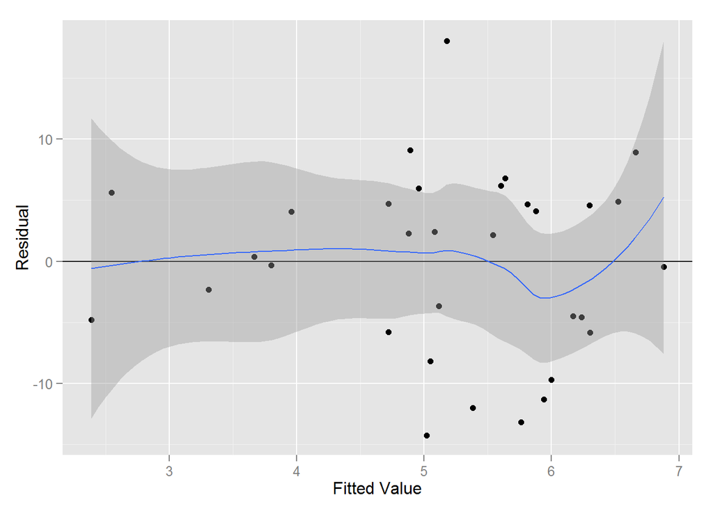

```r
#Checking for randomness in Number of Claim.
g<-ggplot(aes(x=.fitted, y=.resid), data=modCount)+
            geom_point()+geom_hline(yintercept=0)+
            geom_smooth(se=TRUE)+
            labs(x="Fitted Value", y="Residual")
print(g)
```

The coefficient plot below shows the significance of the predictor variables to the response variable. This will help us to visualize the significance strength for each covariate. The further the variable is from the zero x intercept, the more significant the variable is.

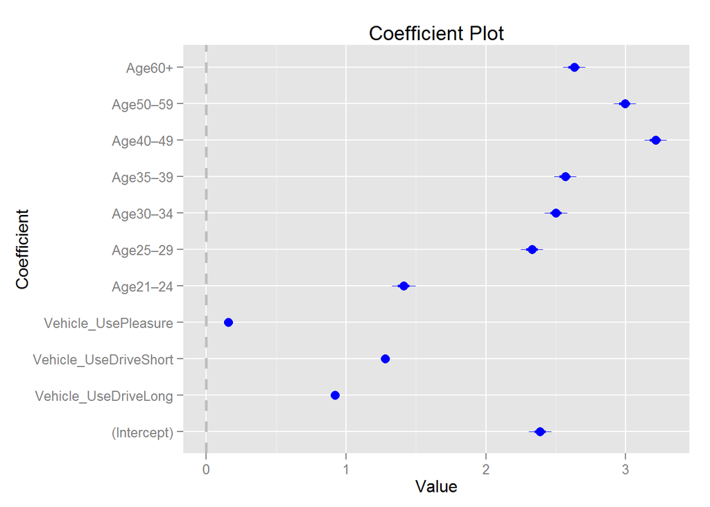

```r
coefplot(modCount)
```

## Severity Modeling.

Similar to the approach for Number of Claims, Severity was modeled using GLM with a Gamma distribution. The analysis revealed that Vehicle_Use significantly influences the response variable more than Age. Some covariates, appearing insignificant, may be either eliminated or merged through further engineering for optimized pricing strategies.

The Vehicle_Use variable is highly significant to the response variable than the Age variable.

```r
Sevtype3<-aov(Severity~Vehicle_Use+Age, data=ACollison)
summary(Sevtype3)
```

```
##             Df Sum Sq Mean Sq F value   Pr(>F)
## Vehicle_Use  3 161818   53939   8.298 0.000786 ***
## Age          7  79830   11404   1.755 0.150349
## Residuals   21 136500    6500
## ---
## Signif. codes:  0 '***' 0.001 '**' 0.01 '*' 0.05 '.' 0.1 ' ' 1
```

There are covariates that are not significant and can be eliminated or combined through further engineering. We can also check for outliers on the respective aggregated groups.

```r
modSev<-glm(Severity~Vehicle_Use+Age, data=ACollison, family = Gamma(link="log"))
summary(modSev)
```

```
##
## Call:
## glm(formula = Severity ~ Vehicle_Use + Age, family = Gamma(link = "log"),
##     data = ACollison)
##
## Deviance Residuals:
##      Min        1Q    Median        3Q       Max
## -0.36150  -0.07282  -0.00603   0.05880   0.47548
##
## Coefficients:
##                       Estimate Std. Error t value Pr(>|t|)
## (Intercept)            6.24125    0.10148  61.500  < 2e-16 ***
## Vehicle_UseDriveLong  -0.35729    0.08655  -4.128 0.000478 ***
## Vehicle_UseDriveShort -0.50531    0.08655  -5.839 8.53e-06 ***
## Vehicle_UsePleasure   -0.58859    0.08655  -6.801 1.00e-06 ***
## Age2124              -0.20798    0.12239  -1.699 0.104035
## Age2529              -0.23028    0.12239  -1.881 0.073846 .
## Age3034              -0.26304    0.12239  -2.149 0.043436 *
## Age3539              -0.53105    0.12239  -4.339 0.000289 ***
## Age4049              -0.38201    0.12239  -3.121 0.005165 **
## Age5059              -0.37410    0.12239  -3.057 0.005993 **
## Age60+                -0.39392    0.12239  -3.218 0.004123 **
## ---
## Signif. codes:  0 '***' 0.001 '**' 0.01 '*' 0.05 '.' 0.1 ' ' 1
##
## (Dispersion parameter for Gamma family taken to be 0.0299607)
##
##     Null deviance: 3.20647  on 31  degrees of freedom
## Residual deviance: 0.58114  on 21  degrees of freedom
## AIC: 343.22
##
## Number of Fisher Scoring iterations: 6
```

### Model Visualization.

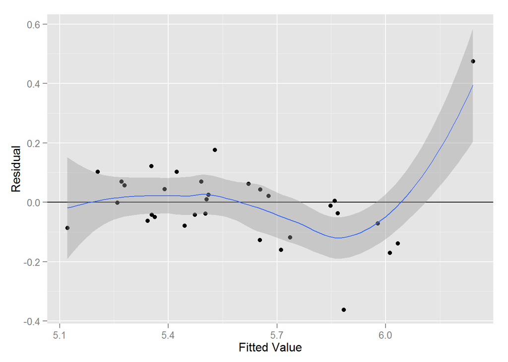

```r
g<-ggplot(aes(x=.fitted, y=.resid), data=modSev)+
            geom_point()+geom_hline(yintercept=0)+
            geom_smooth(se=TRUE)+
            labs(x="Fitted Value", y="Residual")
print(g)
```

The plot for covariate significance is not spread further as compared to the Number of claims. This suggest that the covariate interaction has to be improved through combination. The variables that are not significant in realtion to their respective p-values are usually eliminated when rating the premium cost.

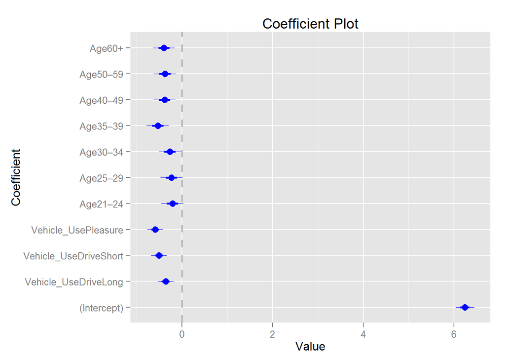

```r
coefplot(modSev)
```

The respective covariates that are not significant with the reference variable can be eliminated from the model or can be combined with certain techniques as a strategy in competitive pricing.

# Table summary

The function that I created below is for summarizing the number of claims and severity model output with their respective exponential values *(Exp)*.

After the whole modeling process, we can now evaluate the premium contribution expected in each risk pool to cover for the claim cost.

```r
#Generating table summary for Number of Claims and Severity Model
tableSum<-function(model,model2){
  #Number of claims table
  covariate<-rownames(as.matrix(model$coefficients))
  Estimate<-model$coefficients
  data1<-data.frame(covariate,Estimate,row.names = NULL)
  #returning log estimate for Number of claims to actual values
  data1$Exp<-exp(data1$Estimate)

  data2<-rbind(data1,data.frame(covariate="Age17-20", Estimate=0, Exp=1))
  data3<-rbind(data2,data.frame(covariate="Vehicle_Business", Estimate=0, Exp=1))
  data4<-data3[order(data3$covariate),]

  #Severity table
  covariate<-rownames(as.matrix(model2$coefficients))
  Estimate<-model2$coefficients
  data1B<-data.frame(covariate,Estimate,row.names = NULL)
  #returning the log estimate for Severity to actual values.
  data1B$Exp<-exp(data1B$Estimate)

  data2B<-rbind(data1B,data.frame(covariate="Age17-20",Estimate=0, Exp=1))
  data3B<-rbind(data2B,data.frame(covariate="Vehicle_Business", Estimate=0, Exp=1))
  data4B<-data3B[order(data3B$covariate),]
  #combining tables from the two models
  data5<-cbind(data4,data4B)
  data5<-data5[,-c(4)]
  names(data5)<-c("covariate", "EstimatePois", "ExpPois", "EstimateGamma","ExpGamma")
  #Renaming "covariate" variables
  data5$covariate<-as.character(c("Intercept","21-24","25-29",
                                 "30-34","35-39","40-49",
                                 "50-59","60+","DriveLong",
                                 "DriveShort", "Pleasure","17-20","Business"))
  return(data5)
}
Output<-tableSum(modCount,modSev)
print(Output)
```

```
##     covariate EstimatePois   ExpPois EstimateGamma    ExpGamma
## 1   Intercept    2.3884105 10.896161     6.2412533 513.5016744
## 5       21-24    1.4124119  4.105846    -0.2079809   0.8122225
## 6       25-29    2.3302929 10.280952    -0.2302796   0.7943115
## 7       30-34    2.5021537 12.208760    -0.2630431   0.7687088
## 8       35-39    2.5676784 13.035527    -0.5310523   0.5879859
## 9       40-49    3.2133836 24.863071    -0.3820124   0.6824866
## 10      50-59    2.9937624 19.960641    -0.3741023   0.6879065
## 11        60+    2.6314624 13.894074    -0.3939240   0.6744053
## 2   DriveLong    0.9198327  2.508871    -0.3572946   0.6995664
## 3  DriveShort    1.2800362  3.596770    -0.5053140   0.6033161
## 4    Pleasure    0.1586523  1.171930    -0.5885861   0.5551116
## 12      17-20    0.0000000  1.000000     0.0000000   1.0000000
## 13   Business    0.0000000  1.000000     0.0000000   1.0000000
```

# Testing the Model.

Based on our model, we want to check as an example, the contribution of premium that will cover for the claim cost for a particular set of risk combination and compare it with the original claim cost. This is reffered to as pure premium. We shall test for risk combination at random to see if the estimated claim cost can cover for the actual claim experiecne for the respective risk pool. I created the summary function below that gave an output summary for risk combination entered in the function in relation to the values from the **Output** and **ACollison** data set. Due to further model improvements that needs to be done, I used the risk combinations that are more stable.

```r
#Testing The Model
Summary<-function(data,data2,AgeRange,Use){
  lookup<-which(data$covariate==AgeRange)
  lookup2<-which(data$covariate==Use)
  lookup3<-which(data$covariate=="Intercept")
  Poid<-data[lookup,c(3)]*data[lookup2,c(3)]*data[lookup3,c(3)]
  Gamm1<-data[lookup,c(5)]*data[lookup2,c(5)]*data[lookup3,c(5)]
  Est<-Poid*Gamm1
#Checking for Main Data Claim Cost
  lookup4<-which(data2$Age==AgeRange&data2$Vehicle_Use==Use)
  data3<-data.frame(Estimate=Est, Actual=data2[lookup4,c(6)],
                    Difference=(Est-data2[lookup4,c(6)]),
                    PercDiff=((Est-data2[lookup4,c(6)])/Est)*100)

return(data3)
}

#Function for generating claim cost estimate and actual cost from respective risk combination
Summary(Output,ACollison,"60+","DriveShort")
```

```
##   Estimate   Actual Difference  PercDiff
## 1 113768.9 113478.7   290.1715 0.2550534
```

As seen from the output, the estimated claim cost for the risk group is higher than the actual claim cost by a slight difference that is less than 0.5%. This suggest that the model can be used to predict the claim cost for the remaining data.

# Conclusion

As seen from the entire process, generalized linear modeling is more refined interms of pricing general insurance products in relation to univariate pricing. This is because the risk is classified into appropriate groups and creates a fair way of pricing insurance products. Further engineering can be done with respective variables by interacting the variables or introducing new variables to the pricing model. The advantage of using generalized linear modeling is that, it can give the insurance company a competitive edge in terms of offering fair premiums to it’s customers. Multivariate pricing is not limited to risk premium modeling only, it can be further used in demand modeling, e.g in renewals and retentions.